# Various Plots and their uses

Scatter, Histogram, Density, Boxplot, Violin, Heatmap & Correlation

Dr. Ankit Deshmukh

2026-09-10

# Introduction

**ggplot2** implements the *Grammar of Graphics*, a systematic approach to building plots layer-by-layer. Every plot follows a consistent structure:

1. **Data** – the dataset
2. **Aesthetics (`aes`)** – map variables to visual properties (x, y, colour, size)
3. **Geoms** – geometric objects (`geom_point()`, `geom_bar()`, …)
4. **Scales** – control mapping from data to visual space
5. **Facets** – sub-plots by categorical variables

This document walks through seven essential chart types, explains **when** to use each, and shows **how** to implement them.

# 1. Scatter Plots

### Utility

- **Purpose**: Visualise the relationship between **two continuous variables**.
- **What to look for**: Direction (positive/negative), form (linear/non-linear), strength (tight vs. loose cluster), and outliers.
- **Best for**: Hypothesis generation about correlation, trend detection, and identifying data gaps.

### Implementation

`geom_point()` is the workhorse. Additional layers like `geom_smooth()` add trend lines.

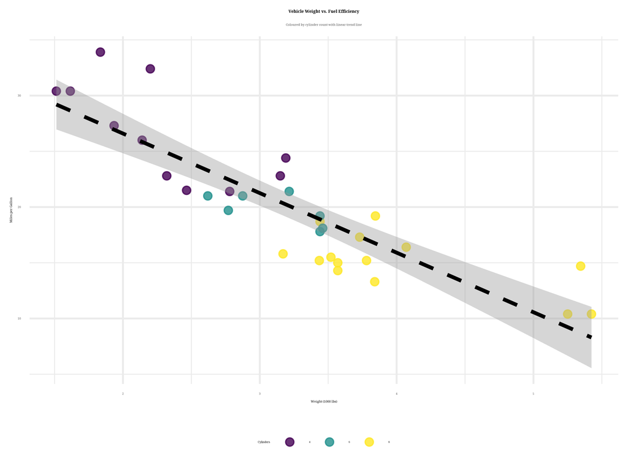

```r
ggplot(mtcars, aes(x = wt, y = mpg)) +
  geom_point(aes(color = factor(cyl)), size = 3, alpha = 0.8) +
  geom_smooth(method = "lm", se = TRUE, color = "black", linetype = "dashed") +
  scale_color_viridis_d(name = "Cylinders") +
  labs(
    title = "Vehicle Weight vs. Fuel Efficiency",
    subtitle = "Coloured by cylinder count with linear trend line",
    x = "Weight (1000 lbs)",
    y = "Miles per Gallon"
  )
```

**Key arguments**: `alpha` for transparency (handles over-plotting), `size` for point emphasis, and `color`/`fill` for grouping.

# 2. Histograms

### Utility

- **Purpose**: Show the **distribution** of a single continuous variable by binning values.
- **What to look for**: Skewness (tail direction), modality (number of peaks), spread, and gaps.
- **Best for**: Initial data exploration, detecting data entry errors, and understanding central tendency.

### Implementation

`geom_histogram()` counts observations per bin. Choose `binwidth` carefully – too wide hides detail, too narrow creates noise.

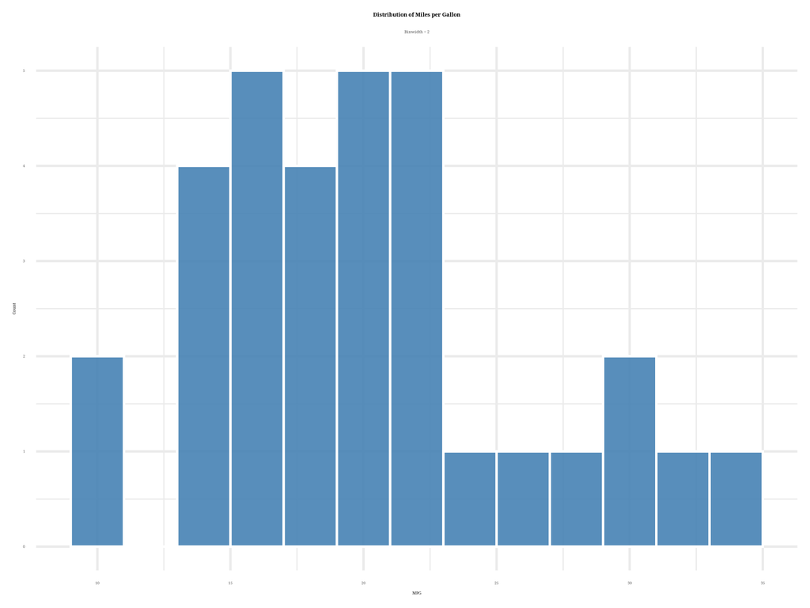

```r
ggplot(mtcars, aes(x = mpg)) +
  geom_histogram(binwidth = 2, fill = "steelblue", color = "white", alpha = 0.9) +
  labs(
    title = "Distribution of Miles per Gallon",
    subtitle = "Binwidth = 2",
    x = "MPG",
    y = "Count"
  )
```

**Tip**: Overlay a density curve (next section) by setting `aes(y = after_stat(density))` to compare the histogram with a smooth estimate.

# 3. Density Plots

### Utility

- **Purpose**: A **smoothed** version of the histogram – estimates the probability density function.
- **What to look for**: Same as histograms, but easier to compare **multiple groups** on the same axes without bin-artefacts.
- **Best for**: Comparing distributions across categories (e.g., MPG by number of cylinders).

### Implementation

`geom_density()` uses a kernel smoother. The `adjust` parameter controls smoothness (higher = smoother).

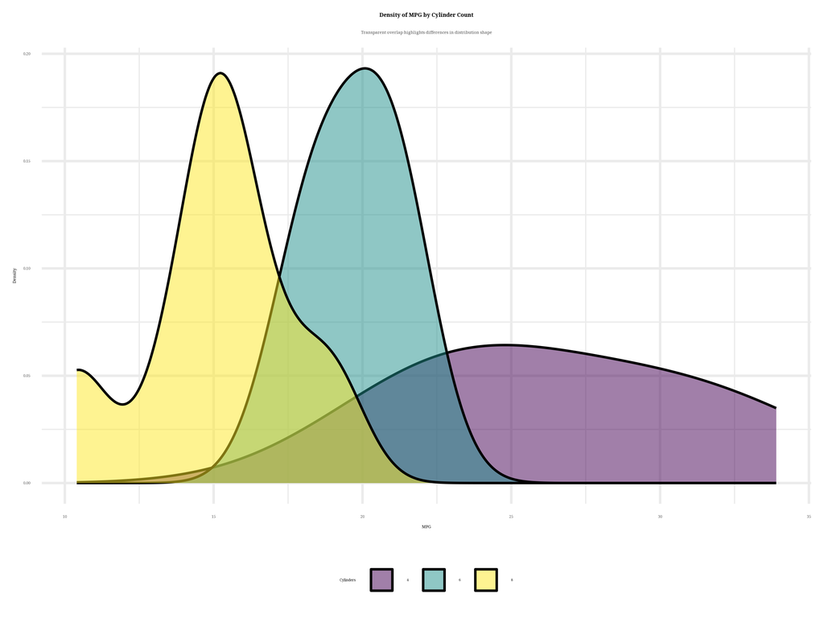

```r
ggplot(mtcars, aes(x = mpg, fill = factor(cyl))) +
  geom_density(alpha = 0.5, adjust = 1.5) +
  scale_fill_viridis_d(name = "Cylinders") +
  labs(
    title = "Density of MPG by Cylinder Count",
    subtitle = "Transparent overlap highlights differences in distribution shape",
    x = "MPG",
    y = "Density"
  )
```

**When to prefer over histograms**: When sample size is small, or you need a clean visual for overlapping groups.

# 4. Boxplots

### Utility

- **Purpose**: Display the **five-number summary** (min, Q1, median, Q3, max) and outliers.
- **What to look for**: Median differences, interquartile range (IQR), symmetry of the middle 50%, and extreme points.
- **Best for**: **Comparing distributions across several categorical groups** in a compact, statistically robust way.

### Implementation

`geom_boxplot()` – whiskers extend to 1.5×IQR; beyond that are plotted as points.

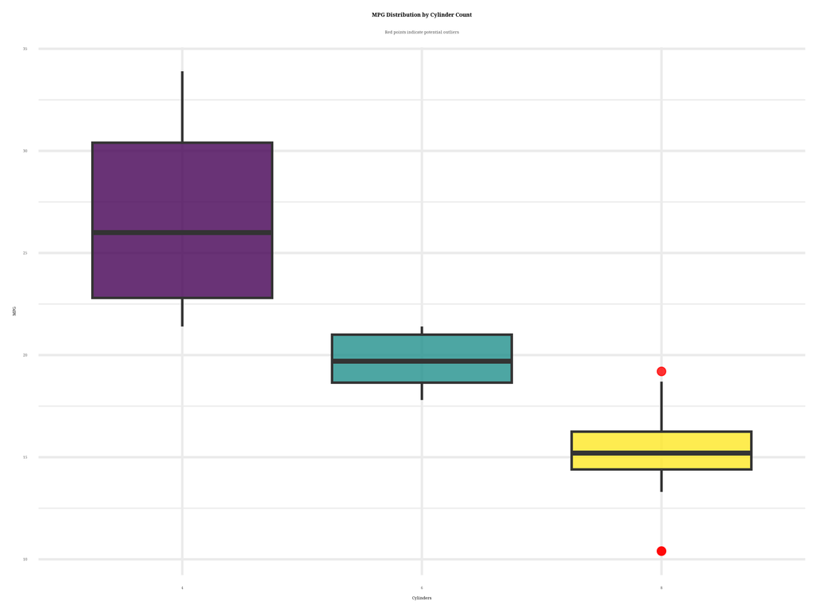

```r
ggplot(mtcars, aes(x = factor(cyl), y = mpg, fill = factor(cyl))) +
  geom_boxplot(outlier.color = "red", outlier.size = 2.5, alpha = 0.8) +
  scale_fill_viridis_d(name = "Cylinders") +
  labs(
    title = "MPG Distribution by Cylinder Count",
    subtitle = "Red points indicate potential outliers",
    x = "Cylinders",
    y = "MPG"
  ) +
  theme(legend.position = "none")
```

**Utility in practice**: Quickly see if groups have different medians, spreads, and whether outliers exist.

# 5. Violin Plots

### Utility

- **Purpose**: Combine a boxplot with a **mirrored density plot** – shows the full shape of the distribution *and* summary statistics.
- **What to look for**: Multi-modality (multiple peaks) within groups, which boxplots hide.
- **Best for**: Rich group comparisons when you suspect complex distributions (e.g., bimodal data).

### Implementation

`geom_violin()` with `trim = FALSE` keeps the tails. Add `draw_quantiles` to overlay quartile lines.

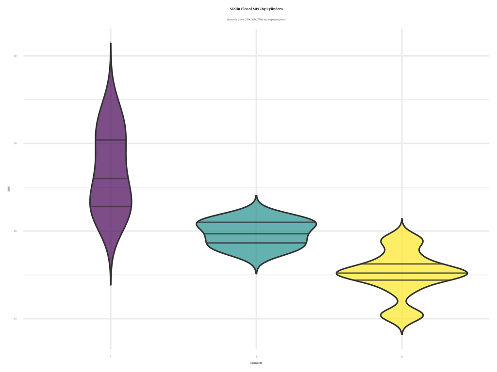

```r
ggplot(mtcars, aes(x = factor(cyl), y = mpg, fill = factor(cyl))) +
  geom_violin(trim = FALSE, draw_quantiles = c(0.25, 0.5, 0.75), alpha = 0.7) +
  scale_fill_viridis_d(name = "Cylinders") +
  labs(
    title = "Violin Plot of MPG by Cylinders",
    subtitle = "Quartile lines (25%, 50%, 75%) are superimposed",
    x = "Cylinders",
    y = "MPG"
  ) +
  theme(legend.position = "none")
```

**Combination tip**: Overlay `geom_boxplot(width = 0.1)` on top of a violin to keep the summary visible while showing the density.